# Effects of Flight Characteristics on Flight Status

## by Jennifer Powell

## Investigation Overview

In this investigation, I wanted to look at all of the characteristics of flight status to determine the causes of delayed and cancelled flights.

## Dataset Overview

The data consisted of attributes for approximately 9723516 flights, within 3 years of data . I was primarily interested in the delays, cancellations, departure airport, departure date, destination airport, and distance flown. I created a subset of the data by determining the 10 busiest airports and using only flights originating out of those airports. This new subset consisted of 3602737 rows.

## Overview of the data

> This will show the % ontime, diverted, cancelled, and delayed flights. Total flights flown, by carrier and distance

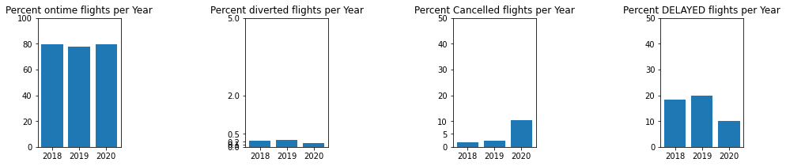

```python
fig = plt.figure(figsize = [16,3])

plt.subplot(1,4, 1)
ot = round((ontime_df.groupby(['YEAR'])['FLIGHTS'].sum() - (ontime_df.groupby(['YEAR'])['DIVERTED'].sum() + ontime_df.groupby(['YEAR'])['CANCELLED'].sum() + ontime_df.groupby(['YEAR'])['DELAYED'].sum()))/ontime_df.groupby(['YEAR'])['FLIGHTS'].sum()*100, 2)
plt.bar(ot.index,ot.values)
plt.xticks([2018,2019,2020]);
plt.yticks(np.arange(0,101,20))
plt.title('Percent ontime flights per Year');
plt.subplots_adjust(wspace = 1.5)

ax = plt.subplot(1,4, 2)
div = round(ontime_df.groupby(['YEAR'])['DIVERTED'].sum()/ontime_df.groupby(['YEAR'])['FLIGHTS'].sum()*100, 2)
plt.bar(div.index,div.values)
plt.xticks([2018,2019,2020]);
plt.title('Percent diverted flights per Year')
plt.yticks([0.0,  0.10, 0.20,  0.50, 2, 5]);
plt.subplots_adjust(wspace = 1.5)

ax = plt.subplot(1,4, 3)
canc = round(ontime_df.groupby(['YEAR'])['CANCELLED'].sum()/ontime_df.groupby(['YEAR'])['FLIGHTS'].sum()*100, 2)
plt.bar(canc.index,canc.values)
plt.xticks([2018,2019,2020]);
plt.yticks([0,5,10,20,30,40,50])
plt.title('Percent Cancelled flights per Year')
plt.subplots_adjust(wspace = 1.5)

ax = plt.subplot(1,4, 4)
delayed = round(ontime_df.groupby(['YEAR'])['DELAYED'].sum()/ontime_df.groupby(['YEAR'])['FLIGHTS'].sum()*100, 2)
plt.bar(delayed.index,delayed.values)
plt.xticks([2018,2019,2020]);
plt.yticks(np.arange(0,60,10));
plt.title('Percent DELAYED flights per Year');
```

> These aren't all on the same scale, so it's a little hard to tell, but you can see that 2020 had a huge increase in cancelled flights (Covid related), with the delays going down instead.

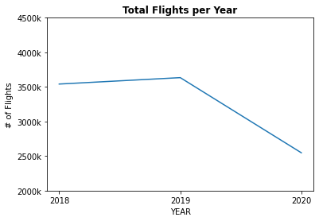

```python
ontime_df.groupby(['YEAR'])['FLIGHTS'].sum().plot()
plt.xticks([2018, 2019, 2020])
plt.yticks(np.arange(2000000,5000000,500000),['2000k','2500k','3000k','3500k','4000k','4500k'])
plt.ylabel('# of Flights')
plt.title('Total Flights per Year', fontweight='bold');
```

> Something to consider when looking at 2020 data is that there were almost 1,000,000 less flights than 2018 and 2019.

##### Breakdown of those flights by Carrier

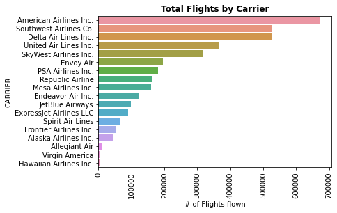

```python
cat_order = subset_top10_or_df['CARRIER'].value_counts().index

sb.countplot(data = subset_top10_or_df, y = 'CARRIER',order=cat_order)
plt.xticks(rotation = 90);
plt.title('Total Flights by Carrier', fontweight='bold');
plt.xlabel('# of Flights flown');
```

> THere are no surprises here, with the big 5 representing the 5 most flights flown

##### Average Distances flown per carrier

> Hawaiian airlines has a very small range of distances (maybe 2500-2800) and also flies the furthest distances. Virgin and Alaskan are a close second, though Virign is left skewed. Some of the outliers seem like they could be errors.

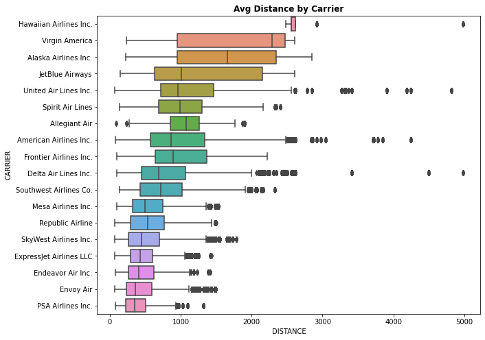

```python
plt.figure(figsize = (10,8))
#sorted_counts = subset_top10_or_df['CARRIER'].value_counts().index
sorted_counts =subset_top10_or_df.groupby('CARRIER')['DISTANCE'].mean().sort_values(axis=0,ascending=False).index

ax = sb.boxplot(y="CARRIER", x="DISTANCE", data=subset_top10_or_df, order=sorted_counts);
plt.title('Avg Distance by Carrier', fontweight='bold');
```

## Cancellations by year and type

##### Break down the cancellations by year and percentage of all cancellations by type

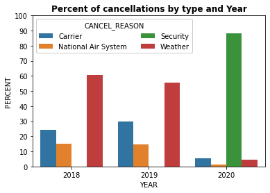

```python
canc_reason = ontime_df.groupby(['YEAR','CANCEL_REASON']).CANCEL_REASON.count()*100/ontime_df.groupby(['YEAR'])['CANCELLED'].sum()
canc_reason = canc_reason.reset_index()
canc_reason.columns = ['YEAR','CANCEL_REASON', 'PERCENT']

ax = sb.barplot(data = canc_reason, x = 'YEAR', y = 'PERCENT', hue = 'CANCEL_REASON')
ax.legend(loc = 'best', ncol = 2, framealpha = 1, title = 'CANCEL_REASON')
ax.set_yticks([0,10,20,30,40,50,60,70,80,90,100]);
plt.title('Percent of cancellations by type and Year', fontweight='bold');
```

> Again, we can see that almost 90% of 2020 cancellations were of type Security. These cancellations represented about 10% of the total flights for 2020. Let's look at the total number of flights to see how this relates.

## Cancelled flights vs Distance

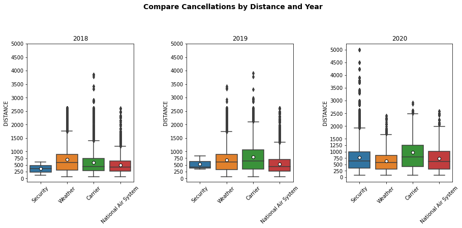

```python
plt.figure(figsize = [15, 5])
base_color = sb.color_palette()[0]
sorted_counts = subset_top10_or_df['CANCEL_REASON'].value_counts().index

plt.subplot(1,3,1)
ax = sb.boxplot(x="CANCEL_REASON", y="DISTANCE", data=subset_top10_or_df[subset_top10_or_df.YEAR==2018],
                order=sorted_counts, showmeans=True,
               meanprops={"marker":"o",
                           "markerfacecolor":"white",
                           "markeredgecolor":"black",
                          "markersize":"6"})
ax.set_yticks([0,250,500,750,1000,1500,2000,2500,3000,3500,4000,4500,5000]);
plt.xticks(rotation = 45)
plt.title('2018')
plt.xlabel('')
plt.subplots_adjust(wspace = 0.5);
plt.subplot(1, 3,2)
ax = sb.boxplot(x="CANCEL_REASON", y="DISTANCE", data=subset_top10_or_df[subset_top10_or_df.YEAR==2019],
                order=sorted_counts, showmeans=True,
                meanprops={"marker":"o",
                            "markerfacecolor":"white",
                            "markeredgecolor":"black",
                            "markersize":"6"})
ax.set_yticks([0,250,500,750,1000,1500,2000,2500,3000,3500,4000,4500,5000]);
plt.xticks(rotation = 45)
plt.title('2019')
plt.xlabel('')
plt.subplots_adjust(wspace = 0.5);

plt.subplot(1, 3, 3)
ax = sb.boxplot(x="CANCEL_REASON", y="DISTANCE", data=subset_top10_or_df[subset_top10_or_df.YEAR==2020],
                order=sorted_counts, showmeans=True,
               meanprops={"marker":"o",
                            "markerfacecolor":"white",
                            "markeredgecolor":"black",
                            "markersize":"6"})

ax.set_yticks([0,250,500,750,1000,1250,1500,2000,2500,3000,3500,4000,4500,5000]);
plt.xticks(rotation = 45)
plt.title('2020');
plt.xlabel('')
plt.suptitle("Compare Cancellations by Distance and Year", x=0.5, y=1.10, fontsize=14, fontweight="bold")
plt.subplots_adjust(wspace = 0.5);
plt.show();
```

> When broken out by year, there are a lot of outliers in almost every category and year. The median cancellations definitely occur at the lower end of the distance scale. In 2019 and 2020 the carrier cancellations occurred in a larger range of distances. The weather delays seem to be fairly consistant across the years and all seem to have a mean of around 700 miles. The security cancellations (with the exception of covid) seem to occur in the shorter flights with a small range of about 500 miles. The NAS cancellations also tends to be in the shorter flights, though there is a wider range of values.

### Looking at the flight status as a percentage, there is a seasonal pattern (excepting Covid)

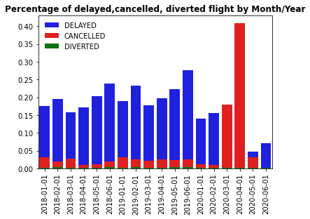

```python
div = subset_top10_or_df.groupby(['MONTH_YEAR'])['DIVERTED'].sum()/subset_top10_or_df.groupby(['MONTH_YEAR'])['FLIGHTS'].sum()
canc = subset_top10_or_df.groupby(['MONTH_YEAR'])['CANCELLED'].sum()/subset_top10_or_df.groupby(['MONTH_YEAR'])['FLIGHTS'].sum()
delay = subset_top10_or_df.groupby(['MONTH_YEAR'])['DELAYED'].sum()/subset_top10_or_df.groupby(['MONTH_YEAR'])['FLIGHTS'].sum()
base_color = sb.color_palette()[0]
sb.barplot(x=delay.index.values, y=delay, color = 'b', label='DELAYED')
sb.barplot(x=canc.index.values, y=canc, color = 'r', label='CANCELLED')
sb.barplot(x=div.index.values, y=div, color = 'g', label='DIVERTED')
plt.xticks(rotation=90);
plt.title('Percentage of delayed,cancelled, diverted flight by Month/Year', fontweight='bold');

plt.legend(frameon = False);
```

> This shows that there is somewhat of a seasonal pattern with flight delays. There is an increase in Feb, then March drops, then there's a gradual increase in each month of April, May and June. With Covid however, this pattern changed completely in 2020. There were almost no delays, only cancellations for March, April and part of May. The cancellations are harder to tell and don't seem to have much of a pattern.

## Weather Delay by month and year

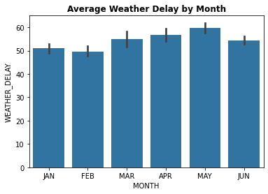

```python
weather_delay = subset_top10_or_df[(subset_top10_or_df.WEATHER_DELAY != 0.0) & (subset_top10_or_df.WEATHER_DELAY.notna())]
base_color = sb.color_palette()[0]

ax = sb.barplot(data = weather_delay, x = 'MONTH', y = 'WEATHER_DELAY', color=base_color)
plt.title('Average Weather Delay by Month', fontweight='bold');
```

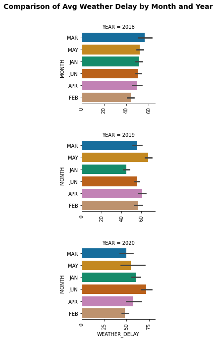

```python
weather_delay = subset_top10_or_df[(subset_top10_or_df.WEATHER_DELAY != 0.0) & (subset_top10_or_df.WEATHER_DELAY.notna())]
order_cnt = weather_delay[weather_delay.YEAR==2018].groupby(['MONTH'])['WEATHER_DELAY'].mean().sort_values(ascending=False).index
g = sb.FacetGrid(weather_delay, col="YEAR",col_wrap=1, height=3,sharex=False)
g.map(sb.barplot,"WEATHER_DELAY",  "MONTH", order=order_cnt, palette="colorblind");
for ax in g.axes:
    plt.setp(ax.get_xticklabels(), visible=True, rotation=90)

plt.subplots_adjust(hspace=.5)
plt.suptitle("Comparison of Avg Weather Delay by Month and Year", x=0.5, y=1.05, fontsize=14, fontweight="bold");

plt.show()
```

> Interestingly, March, May and June seem to have the highest weather delays, depending on the year. I would assume rain and/or ice would be the cause. If you look at combined mean, the highest delays would be May, April and March.

## Carrier Delay by Carrier

#### Here are the carrier delays sorted by Carrier

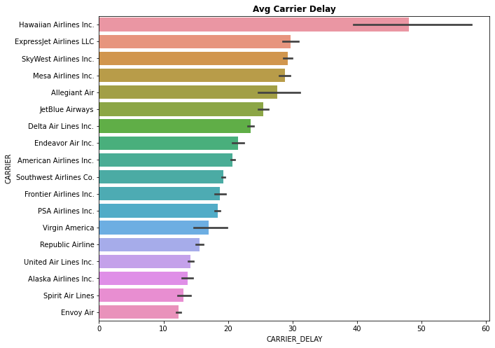

```python
plt.figure(figsize = (10,8))
sorted_counts =subset_top10_or_df.groupby('CARRIER')['CARRIER_DELAY'].mean().sort_values(axis=0,ascending=False).index

ax = sb.barplot(y="CARRIER", x="CARRIER_DELAY", data=subset_top10_or_df, order=sorted_counts);
plt.title('Avg Carrier Delay', fontweight='bold');
```

## Heatmap of avg Weather and NAS delay by Carrier, Origin City and Destination City

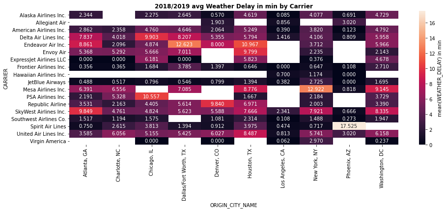

```python
plt.figure(figsize = [15, 5])
cat_means = subset_top10_or_df[subset_top10_or_df.YEAR.isin(['2018','2019'])].groupby(['CARRIER', 'ORIGIN_CITY_NAME']).mean()['WEATHER_DELAY']
cat_means = cat_means.reset_index(name = 'WEATHER_DELAY_avg')
cat_means = cat_means.pivot(index = 'CARRIER', columns = 'ORIGIN_CITY_NAME',
                            values = 'WEATHER_DELAY_avg')
sb.heatmap(cat_means, annot = True, fmt = '.3f',
           cbar_kws = {'label' : 'mean(WEATHER_DELAY) in min'});
plt.title('2018/2019 avg Weather Delay in min by Carrier', fontweight='bold');
```

> This shows the weather delays by city and carrier. Spirit airline seems to have a lot of delays out of Phoenix, while Endeavor has problems out of Dallas and Houston. New York, Denver and Chicago also show longer delays with Mesa, Republic, and PSA showing the longest. Since NAS delays could also be weather related, lets check them as well

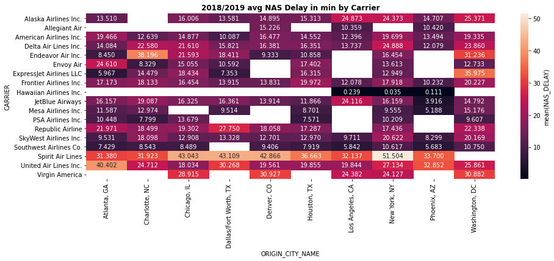

```python
plt.figure(figsize = [15, 5])
cat_means = subset_top10_or_df[subset_top10_or_df.YEAR.isin(['2018','2019'])].groupby(['CARRIER', 'ORIGIN_CITY_NAME']).mean()['NAS_DELAY']
cat_means = cat_means.reset_index(name = 'NAS_DELAY_avg')
cat_means = cat_means.pivot(index = 'CARRIER', columns = 'ORIGIN_CITY_NAME',
                            values = 'NAS_DELAY_avg')
sb.heatmap(cat_means, annot = True, fmt = '.3f',
           cbar_kws = {'label' : 'mean(NAS_DELAY)'});

plt.title('2018/2019 avg NAS Delay in min by Carrier', fontweight='bold');
```

> Spirit and United seem to have the longest avg delays, oddly enough for Spirit it is in almost every city. United shows Atlanta and Phoenix as the highest avg delays.

##### Now lets look at both for Dest city

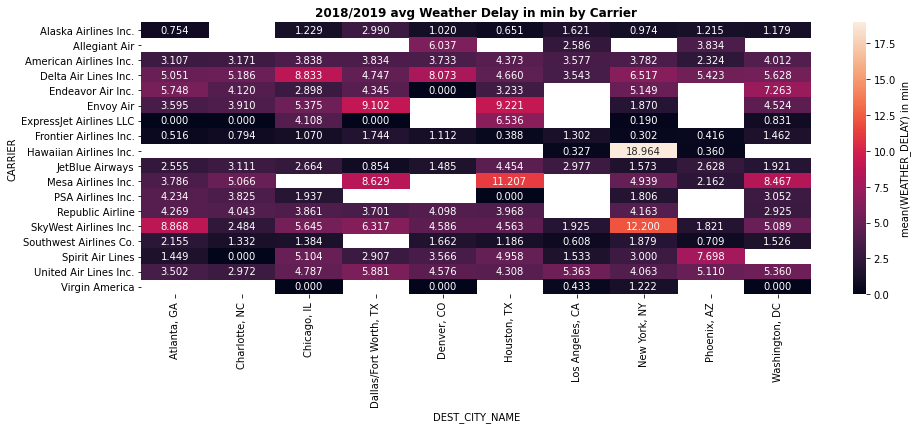

```python
plt.figure(figsize = [15, 5])
cat_means = subset_top10_dst_df[subset_top10_dst_df.YEAR.isin(['2018','2019'])].groupby(['CARRIER', 'DEST_CITY_NAME']).mean()['WEATHER_DELAY']
cat_means = cat_means.reset_index(name = 'WEATHER_DELAY_avg')
cat_means = cat_means.pivot(index = 'CARRIER', columns = 'DEST_CITY_NAME',
                            values = 'WEATHER_DELAY_avg')
sb.heatmap(cat_means, annot = True, fmt = '.3f',
           cbar_kws = {'label' : 'mean(WEATHER_DELAY) in min'});
plt.title('2018/2019 avg Weather Delay in min by Carrier', fontweight='bold');
```

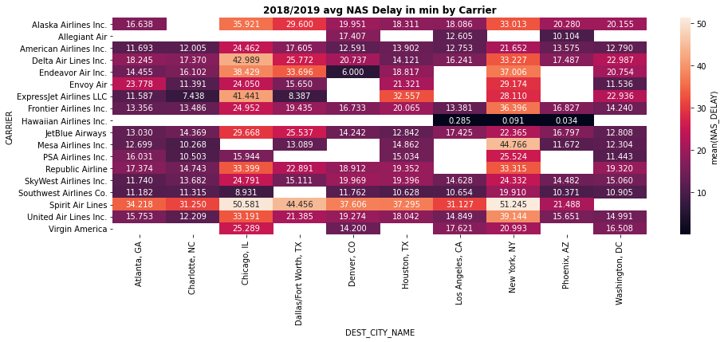

```python
plt.figure(figsize = [15, 5])
cat_means = subset_top10_dst_df[subset_top10_dst_df.YEAR.isin(['2018','2019'])].groupby(['CARRIER', 'DEST_CITY_NAME']).mean()['NAS_DELAY']
cat_means = cat_means.reset_index(name = 'NAS_DELAY_avg')
cat_means = cat_means.pivot(index = 'CARRIER', columns = 'DEST_CITY_NAME',
                            values = 'NAS_DELAY_avg')
sb.heatmap(cat_means, annot = True, fmt = '.3f',
           cbar_kws = {'label' : 'mean(NAS_DELAY)'});

plt.title('2018/2019 avg NAS Delay in min by Carrier', fontweight='bold');
```

> There are fewer weather delays by destination but still the same cities: Atlanta, Chicago, Houston, and New York.
> - It's interesting, there are much more NAS delays at the destination cities: Chicago and New York stand out as the highest. Then again, Spirit Air seems to have delays at all of their destination airport as well

## Effect of time of departure on delays and cancellations

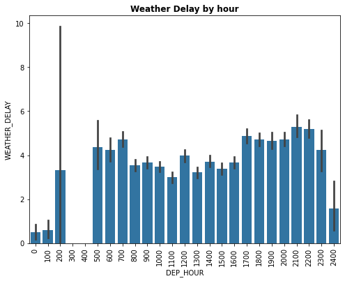

```python
plt.figure(figsize = (8,6))
base_color = sb.color_palette()[0]

sorted_counts =subset_top10_or_df.groupby('DEP_HOUR')['WEATHER_DELAY'].mean().index
sorted_counts
ax = sb.barplot(y="WEATHER_DELAY", x="DEP_HOUR", data=subset_top10_or_df, order=sorted_counts, color=base_color);
plt.title('Weather Delay by hour', fontweight='bold');
plt.xticks(rotation=90);
```

> Looking at the hours of departure, most weather delays occur in the early morning and late afternoon.

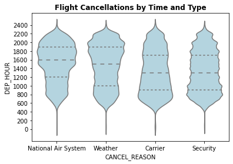

```python
# plot the categorical variables against price and carat again, this time
# with full data and variable transforms
sb.violinplot(data = subset_top10_or_df, y = 'DEP_HOUR', x= 'CANCEL_REASON', color = 'lightblue', inner='quartile')
plt.title('Flight Cancellations by Time and Type', fontweight='bold')
plt.yticks(np.arange(0,2500, 200))
plt.show()
```

> For cancellations, NAS and Weather cancellations occur more frequently in the afternoon, while Carrier and Security cancellations occur more in the morning to late-morning.